# Income analysis using Logistic Regression

#### Setup

first load some library…

```r
library(ggplot2)
library(stats)
library(dplyr)
```

- It’s time to read data…

```r
adult <- read.csv("adult.csv")
head(adult)
```

|  | age | workclass | fnlwgt | education | educational.num | marital.status | occupation | relationship | race | gender | capital.gain | capital.loss | hours.per.week | native.country | income |
| --- | --- | --- | --- | --- | --- | --- | --- | --- | --- | --- | --- | --- | --- | --- | --- |
| 1 | 25 | Private | 226802 | 11th | 7 | Never-married | Machine-op-inspct | Own-child | Black | Male | 0 | 0 | 40 | United-States | <=50K |
| 2 | 38 | Private | 89814 | HS-grad | 9 | Married-civ-spouse | Farming-fishing | Husband | White | Male | 0 | 0 | 50 | United-States | <=50K |
| 3 | 28 | Local-gov | 336951 | Assoc-acdm | 12 | Married-civ-spouse | Protective-serv | Husband | White | Male | 0 | 0 | 40 | United-States | >50K |
| 4 | 44 | Private | 160323 | Some-college | 10 | Married-civ-spouse | Machine-op-inspct | Husband | Black | Male | 7688 | 0 | 40 | United-States | >50K |
| 5 | 18 | ? | 103497 | Some-college | 10 | Never-married | ? | Own-child | White | Female | 0 | 0 | 30 | United-States | <=50K |
| 6 | 34 | Private | 198693 | 10th | 6 | Never-married | Other-service | Not-in-family | White | Male | 0 | 0 | 30 | United-States | <=50K |

- Let’s checkout the structure of the variables and their summary..

```r
str(adult)
```

```
'data.frame':   48842 obs. of  15 variables:
 $ age            : int  25 38 28 44 18 34 29 63 24 55 ...
 $ workclass      : Factor w/ 9 levels "?","Federal-gov",..: 5 5 3 5 1 5 1 7 5 5 ...
 $ fnlwgt         : int  226802 89814 336951 160323 103497 198693 227026 104626 369667 104996 ...
 $ education      : Factor w/ 16 levels "10th","11th",..: 2 12 8 16 16 1 12 15 16 6 ...
 $ educational.num: int  7 9 12 10 10 6 9 15 10 4 ...
 $ marital.status : Factor w/ 7 levels "Divorced","Married-AF-spouse",..: 5 3 3 3 5 5 5 3 5 3 ...
 $ occupation     : Factor w/ 15 levels "?","Adm-clerical",..: 8 6 12 8 1 9 1 11 9 4 ...
 $ relationship   : Factor w/ 6 levels "Husband","Not-in-family",..: 4 1 1 1 4 2 5 1 5 1 ...
 $ race           : Factor w/ 5 levels "Amer-Indian-Eskimo",..: 3 5 5 3 5 5 3 5 5 5 ...
 $ gender         : Factor w/ 2 levels "Female","Male": 2 2 2 2 1 2 2 2 1 2 ...
 $ capital.gain   : int  0 0 0 7688 0 0 0 3103 0 0 ...
 $ capital.loss   : int  0 0 0 0 0 0 0 0 0 0 ...
 $ hours.per.week : int  40 50 40 40 30 30 40 32 40 10 ...
 $ native.country : Factor w/ 42 levels "?","Cambodia",..: 40 40 40 40 40 40 40 40 40 40 ...
 $ income         : Factor w/ 2 levels "<=50K",">50K": 1 1 2 2 1 1 1 2 1 1 ...
```

```r
summary(adult)
```

```
      age                   workclass         fnlwgt               education     educational.num               marital.status            occupation            relationship
 Min.   :17.00   Private         :33906   Min.   :  12285   HS-grad     :15784   Min.   : 1.00   Divorced             : 6633   Prof-specialty : 6172   Husband       :19716
 1st Qu.:28.00   Self-emp-not-inc: 3862   1st Qu.: 117550   Some-college:10878   1st Qu.: 9.00   Married-AF-spouse    :   37   Craft-repair   : 6112   Not-in-family :12583
 Median :37.00   Local-gov       : 3136   Median : 178144   Bachelors   : 8025   Median :10.00   Married-civ-spouse   :22379   Exec-managerial: 6086   Other-relative: 1506
 Mean   :38.64   ?               : 2799   Mean   : 189664   Masters     : 2657   Mean   :10.08   Married-spouse-absent:  628   Adm-clerical   : 5611   Own-child     : 7581
 3rd Qu.:48.00   State-gov       : 1981   3rd Qu.: 237642   Assoc-voc   : 2061   3rd Qu.:12.00   Never-married        :16117   Sales          : 5504   Unmarried     : 5125
 Max.   :90.00   Self-emp-inc    : 1695   Max.   :1490400   11th        : 1812   Max.   :16.00   Separated            : 1530   Other-service  : 4923   Wife          : 2331
                 (Other)         : 1463                     (Other)     : 7625                   Widowed              : 1518   (Other)        :14434
                 race          gender       capital.gain    capital.loss    hours.per.week        native.country    income
 Amer-Indian-Eskimo:  470   Female:16192   Min.   :    0   Min.   :   0.0   Min.   : 1.00   United-States:43832   <=50K:37155
 Asian-Pac-Islander: 1519   Male  :32650   1st Qu.:    0   1st Qu.:   0.0   1st Qu.:40.00   Mexico       :  951   >50K :11687
 Black             : 4685                  Median :    0   Median :   0.0   Median :40.00   ?            :  857
 Other             :  406                  Mean   : 1079   Mean   :  87.5   Mean   :40.42   Philippines  :  295
 White             :41762                  3rd Qu.:    0   3rd Qu.:   0.0   3rd Qu.:45.00   Germany      :  206
                                           Max.   :99999   Max.   :4356.0   Max.   :99.00   Puerto-Rico  :  184
                                                                                            (Other)      : 2517
```

### Data Cleaning

We have a lot of categorical variables, with too many factors that may be neccessary for model building. In this section, we’ll collapse factors for these columns into fewer categories.

#### Type Employer

Let’s check out the frequency of the different factor levels in this column.

```r
table(adult$workclass)
```

```
               ?      Federal-gov        Local-gov     Never-worked          Private     Self-emp-inc Self-emp-not-inc        State-gov      Without-pay
            2799             1432             3136               10            33906             1695             3862             1981               21
```

We’ll combine similar looking factor levels into single levels.

```r
levels(adult$workclass)[4] <- "Unemployed"
levels(adult$workclass)[9] <- "Unemployed"
levels(adult$workclass)[3] <- "SL-gov"
levels(adult$workclass)[8] <- "SL-gov"
levels(adult$workclass)[6:7] <- "self-emp"
```

Okay, Now re-check it…

```r
table(adult$workclass)
```

```
          ? Federal-gov      SL-gov  Unemployed     Private    self-emp
       2799        1432        5117          31       33906        5557
```

#### Marital Status

- We’ll do the same for this column.

```r
levels(adult$marital.status)[1] <- "Not-Married"
levels(adult$marital.status)[6:7] <- "Not-Married"
levels(adult$marital.status)[2:4] <- "Married"
table(adult$marital.status)
```

```
  Not-Married       Married Never-married
         9681         23044         16117
```

#### Countries into region

Again, We have too many countries to deal with. It makes sense to convert them into regions. Let’s build vectors for regions.

```r
Asia <-c('China','Hong','India','Iran','Cambodia','Japan', 'Laos' ,
          'Philippines' ,'Vietnam' ,'Taiwan', 'Thailand')
North.America <- c('Canada','United-States','Puerto-Rico' )
Europe <- c('England' ,'France', 'Germany' ,'Greece','Holand-Netherlands','Hungary',
            'Ireland','Italy','Poland','Portugal','Scotland','Yugoslavia')
Latin.and.South.America <- c('Columbia','Cuba','Dominican-Republic','Ecuador',
                             'El-Salvador','Guatemala','Haiti','Honduras',
                             'Mexico','Nicaragua','Outlying-US(Guam-USVI-etc)','Peru',
                            'Jamaica','Trinadad&Tobago')
Other <- c('South')
```

- Function to set county according to their continent…

```r
group_country <- function(ctry){
  if(ctry %in% Asia){
      return ('Asia')
  }else if(ctry %in% North.America){
    return('North.America')
  }else if(ctry %in% Europe){
    return('Europe')
  }else if(ctry %in% Latin.and.South.America){
    return('Latin.and.South.America')
  }else {
    return ('Other')
  }
}
```

- Now time to apply our above function…

```r
adult$native.country <- sapply(adult$native.country,group_country)
```

```r
colnames(adult)[14] <- "region"
table(adult$region)
```

```
                   Asia                  Europe Latin.and.South.America           North.America                   Other
                    981                     780                    1911                   44198                     972
```

### Missing Data

- Now it’s time to deal with missing data…

```r
# Load library first
library(Amelia)
```

```r
adult[adult=="?"]<-NA
```

Refactoring the columns…

```r
adult$workclass <- factor(adult$workclass)
adult$region <- factor(adult$region)
adult$marital.status <- factor(adult$marital.status)
adult$occupation <- factor(adult$occupation)
```

- Creating a missing map for the data

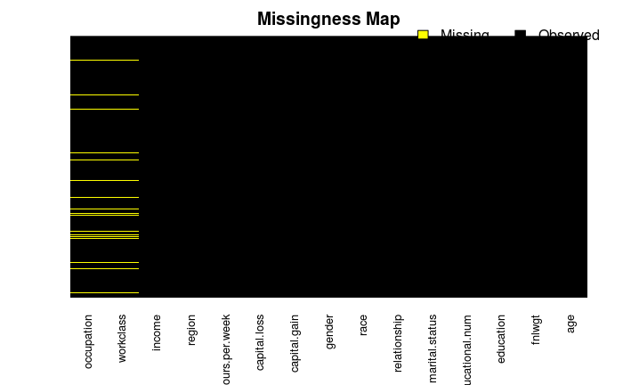

```r
missmap(adult,y.at = c(1),y.labels = c(" "),col=c("yellow","black"))
```

- Ommiting missing vales…

```r
adult <- na.omit(adult)
```

- Now, check missing map again for conformation…

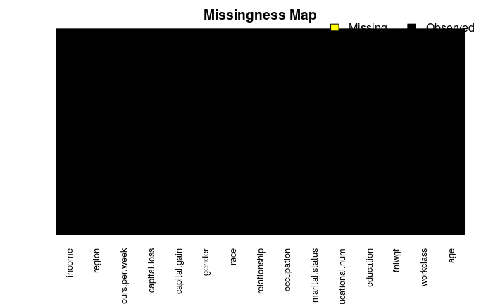

```r
missmap(adult,y.at = c(1),y.labels = c(" "),col=c("yellow","black"))
```

- Wow !!! Missing data is now gone….

### Exploratory Data Analysis

- Histogram of ages, by income…

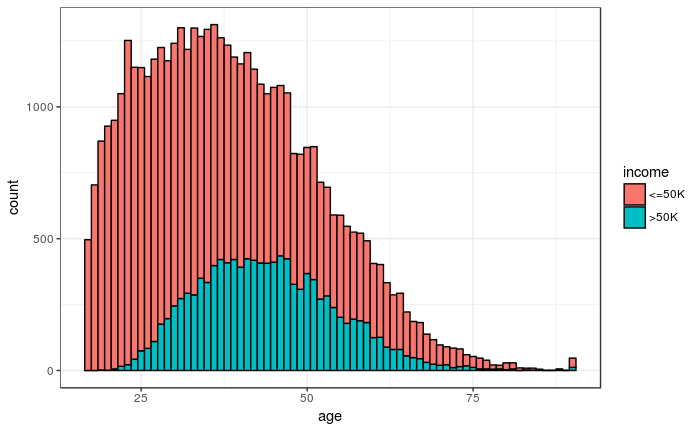

```r
ggplot(adult,aes(age)) + geom_histogram(aes(fill=income),color='black',binwidth = 1)+theme_bw()
```

- Histogram of hours worked per week…

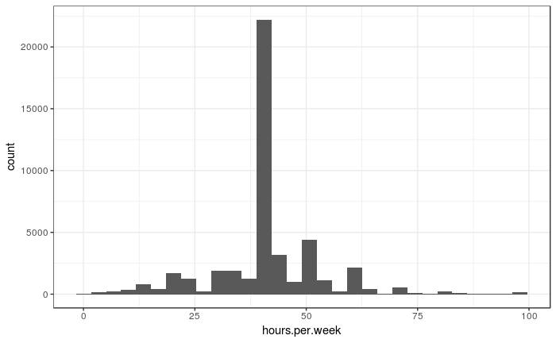

```r
ggplot(adult,aes(hours.per.week))+geom_histogram()+theme_bw()
```

- Barplot of region filled by income class…

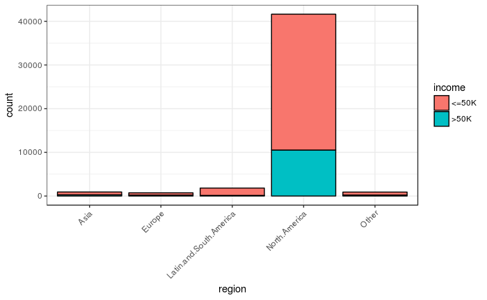

```r
ggplot(adult,aes(region))+geom_bar(aes(fill=income),color="black")+theme_bw()+theme(axis.text.x = element_text(angle = 45,hjust=1))
```

### Model Building

- Now, we’ll build a model to classify people into two groups: above or below 50k in salary. It makes sense to use logistic regression here as we’re trying to predict binary outcome.
- Splitting data for training set

```r
library(caTools)
# Splitting the data into 70% training and 30% test
sample <- sample.split(adult$income,SplitRatio = 0.7)
train <- subset(adult,sample==TRUE)
test <- subset(adult,sample==FALSE)
```

- check data in test and train

```r
head(test)
```

|  | age | workclass | fnlwgt | education | educational.num | marital.status | occupation | relationship | race | gender | capital.gain | capital.loss | hours.per.week | region | income |
| --- | --- | --- | --- | --- | --- | --- | --- | --- | --- | --- | --- | --- | --- | --- | --- |
| 3 | 28 | SL-gov | 336951 | Assoc-acdm | 12 | Married | Protective-serv | Husband | White | Male | 0 | 0 | 40 | North.America | >50K |
| 4 | 44 | Private | 160323 | Some-college | 10 | Married | Machine-op-inspct | Husband | Black | Male | 7688 | 0 | 40 | North.America | >50K |
| 9 | 24 | Private | 369667 | Some-college | 10 | Never-married | Other-service | Unmarried | White | Female | 0 | 0 | 40 | North.America | <=50K |
| 13 | 26 | Private | 82091 | HS-grad | 9 | Never-married | Adm-clerical | Not-in-family | White | Female | 0 | 0 | 39 | North.America | <=50K |
| 15 | 48 | Private | 279724 | HS-grad | 9 | Married | Machine-op-inspct | Husband | White | Male | 3103 | 0 | 48 | North.America | >50K |
| 18 | 43 | Private | 128354 | HS-grad | 9 | Married | Adm-clerical | Wife | White | Female | 0 | 0 | 30 | North.America | <=50K |

```r
head(train)
```

|  | age | workclass | fnlwgt | education | educational.num | marital.status | occupation | relationship | race | gender | capital.gain | capital.loss | hours.per.week | region | income |
| --- | --- | --- | --- | --- | --- | --- | --- | --- | --- | --- | --- | --- | --- | --- | --- |
| 1 | 25 | Private | 226802 | 11th | 7 | Never-married | Machine-op-inspct | Own-child | Black | Male | 0 | 0 | 40 | North.America | <=50K |
| 2 | 38 | Private | 89814 | HS-grad | 9 | Married | Farming-fishing | Husband | White | Male | 0 | 0 | 50 | North.America | <=50K |
| 6 | 34 | Private | 198693 | 10th | 6 | Never-married | Other-service | Not-in-family | White | Male | 0 | 0 | 30 | North.America | <=50K |
| 8 | 63 | self-emp | 104626 | Prof-school | 15 | Married | Prof-specialty | Husband | White | Male | 3103 | 0 | 32 | North.America | >50K |
| 10 | 55 | Private | 104996 | 7th-8th | 4 | Married | Craft-repair | Husband | White | Male | 0 | 0 | 10 | North.America | <=50K |
| 11 | 65 | Private | 184454 | HS-grad | 9 | Married | Machine-op-inspct | Husband | White | Male | 6418 | 0 | 40 | North.America | >50K |

- Creating the model…

```r
model <- glm(income ~ .,family = binomial(logit),data=train)
```

```
glm.fit: fitted probabilities numerically 0 or 1 occurred
```

```r
summary(model)
```

```
Call:
glm(formula = income ~ ., family = binomial(logit), data = train)

Deviance Residuals:
    Min       1Q   Median       3Q      Max
-5.2169  -0.5163  -0.1936  -0.0196   3.7026

Coefficients: (1 not defined because of singularities)
                                Estimate Std. Error z value Pr(>|z|)
(Intercept)                   -6.564e+00  3.972e-01 -16.526  < 2e-16 ***
age                            2.459e-02  1.638e-03  15.018  < 2e-16 ***
workclassSL-gov               -7.115e-01  1.022e-01  -6.961 3.38e-12 ***
workclassUnemployed           -1.121e+00  8.127e-01  -1.379 0.167845
workclassPrivate              -4.853e-01  9.084e-02  -5.343 9.16e-08 ***
workclassself-emp             -7.827e-01  1.009e-01  -7.753 8.95e-15 ***
fnlwgt                         7.358e-07  1.690e-07   4.355 1.33e-05 ***
education11th                  2.580e-01  2.160e-01   1.194 0.232293
education12th                  8.394e-01  2.622e-01   3.202 0.001367 **
education1st-4th              -5.493e-01  5.306e-01  -1.035 0.300535
education5th-6th               4.282e-02  3.194e-01   0.134 0.893331
education7th-8th              -2.347e-01  2.353e-01  -0.997 0.318604
education9th                   5.321e-02  2.591e-01   0.205 0.837304
educationAssoc-acdm            1.586e+00  1.849e-01   8.577  < 2e-16 ***
educationAssoc-voc             1.443e+00  1.794e-01   8.047 8.49e-16 ***
educationBachelors             2.080e+00  1.676e-01  12.410  < 2e-16 ***
educationDoctorate             2.909e+00  2.199e-01  13.227  < 2e-16 ***
educationHS-grad               9.860e-01  1.638e-01   6.020 1.74e-09 ***
educationMasters               2.362e+00  1.767e-01  13.362  < 2e-16 ***
educationPreschool            -4.181e+00  3.162e+00  -1.322 0.186014
educationProf-school           2.908e+00  2.102e-01  13.835  < 2e-16 ***
educationSome-college          1.306e+00  1.660e-01   7.866 3.65e-15 ***
educational.num                       NA         NA      NA       NA
marital.statusMarried          9.317e-01  1.607e-01   5.797 6.75e-09 ***
marital.statusNever-married   -4.796e-01  8.193e-02  -5.854 4.81e-09 ***
occupationArmed-Forces         2.018e-01  9.218e-01   0.219 0.826740
occupationCraft-repair        -1.442e-02  7.780e-02  -0.185 0.852954
occupationExec-managerial      7.537e-01  7.489e-02  10.064  < 2e-16 ***
occupationFarming-fishing     -1.202e+00  1.374e-01  -8.744  < 2e-16 ***
occupationHandlers-cleaners   -7.461e-01  1.383e-01  -5.394 6.89e-08 ***
occupationMachine-op-inspct   -3.348e-01  9.789e-02  -3.420 0.000625 ***
```

[output cut: 19 more lines]

```
hours.per.week                 3.039e-02  1.623e-03  18.728  < 2e-16 ***
regionEurope                   5.123e-01  2.140e-01   2.394 0.016644 *
regionLatin.and.South.America -3.073e-01  2.139e-01  -1.437 0.150826
regionNorth.America            4.060e-01  1.711e-01   2.372 0.017676 *
regionOther                   -3.653e-02  1.950e-01  -0.187 0.851390
---
Signif. codes:  0 ‘***’ 0.001 ‘**’ 0.01 ‘*’ 0.05 ‘.’ 0.1 ‘ ’ 1

(Dispersion parameter for binomial family taken to be 1)

    Null deviance: 36106  on 32222  degrees of freedom
Residual deviance: 20897  on 32169  degrees of freedom
AIC: 21005

Number of Fisher Scoring iterations: 8
```

- Removing unimportant features iteratively using ‘step’…

```r
new.step.model <- step(model)
```

[output not shown]

[output not shown]

[output not shown]

[output not shown]

[output not shown]

- Predictions and Checking results, we’ll use the new step model for this…

```r
test$predicted.income <- predict(new.step.model,newdata=test,type="response")
table(test$income,test$predicted.income>0.5)
```

```
        FALSE TRUE
  <=50K  9631  752
  >50K   1323 2104
```